# Regression Model for Bike Sharing Using R - Take 2

David Lowe

May 29, 2018

Template Credit: Adapted from a template made available by Dr. Jason Brownlee of Machine Learning Mastery (http://machinelearningmastery.com/)

Dataset Used: Bike Sharing Dataset

Dataset ML Model: Regression with numerical attributes

Dataset Reference: https://archive.ics.uci.edu/ml/datasets/Bike+Sharing+Dataset

For performance benchmarks, please consult: https://www.kaggle.com/contactprad/bike-share-daily-data

INTRODUCTION: Using the data generated by a bike sharing system, this project attempts to predict the daily demand for bike sharing. For this iteration (Take No.2) of the project, we attempt to use the data available, transform as necessary, and apply the Stochastic Gradient Boosting algorithm to examine the modeling effectiveness. Again, the goal of this iteration is to examine various data transformation options and find a sufficiently accurate (low error) combination for future prediction tasks.

Scenario No.1: Remove the attribute “atemp” since it was highly correlated with the attribute “temp.” Scenario No.2: Perform one-hot-encoding on the variable “season.” Scenario No.3: Perform one-hot-encoding on the variable “mnth.”

CONCLUSION: The baseline performance of the Stochastic Gradient Boosting stands at an RMSE value of 1240 and an R-square value of 0.5943 using the training data. Scenario No.1 did slightly better with an RMSE value of 1233 and an R-square value of 0.5991. As the result, we will leverage scenario No.1 to training the final model and observe how it will do with the validation dataset.

The final Stochastic Gradient Boosting model processed the validation dataset with an RMSE value of 1180 and an R-square value of 0.6320, which was slightly worse than the Take No.1 result of 1177 for RMSE and 0.6329 for R-square. For this iteration of the project, data transformation did not improve the model performance with a noticeable outcome.

The purpose of this project is to analyze predictions using various machine learning algorithms and to document the steps using a template. Working through machine learning problems from end-to-end requires a structured modeling approach. Working problems through a project template can also encourage us to think about the problem more critically, to challenge our assumptions, and to get proficient at all parts of a modeling project.

The project aims to touch on the following areas:

1. Document a predictive modeling problem end-to-end.
2. Explore data cleaning and transformation options
3. Explore non-ensemble and ensemble algorithms for baseline model performance
4. Explore algorithm tuning techniques for improving model performance

Any predictive modeling machine learning project genrally can be broken down into about six major tasks:

1. Prepare Problem
2. Summarize Data
3. Prepare Data
4. Model and Evaluate Algorithms
5. Improve Accuracy or Results
6. Finalize Model and Present Results

## 1. Prepare Problem

### 1.a) Load libraries

```r
library(caret)
```

```r
library(corrplot)
library(dummies)
```

### 1.b) Load dataset

```r
startTimeScript <- proc.time()
entireDataset <- read.csv("bike-sharing-day.csv", header= TRUE)

# We are making some preliminary assumptions to drop certain attributes right from the beginning.
# Assumption #1: Drop the "instant" column since it is just an unique row identifier.
# Assumption #2: Drop the "detday" column since it is just an unique date field.
# Assumption #3: Drop the "yr" column since it was just an date representation and a one-time occurance.
# Assumption #4: Drop the "casual" and "registered" columns since they are just derived number from the target variable and directly correlate with it.
entireDataset$instant <- NULL
entireDataset$dteday <- NULL
entireDataset$yr <- NULL
entireDataset$casual <- NULL
entireDataset$registered <- NULL

# Use variable totCol to hold the number of columns in the dataframe
totCol <- ncol(entireDataset)

# Rename the class/target column to a standard label
colnames(entireDataset)[ncol(entireDataset)] <- "targetVar"

# Save a copy of the entireDataset for re-use by each of the scenarios
entireDataset.save <- entireDataset
```

## 2. Summarize Data

To gain a better understanding of the data that we have on-hand, we will leverage a number of descriptive statistics and data visualization techniques. The plan is to use the results to consider new questions, review assumptions, and validate hypotheses that we can investigate later with specialized models.

### 2.a) Descriptive statistics

#### 2.a.i) Peek at the data itself.

```r
head(entireDataset)
```

```
##   season mnth holiday weekday workingday weathersit     temp    atemp
## 1      1    1       0       6          0          2 0.344167 0.363625
## 2      1    1       0       0          0          2 0.363478 0.353739
## 3      1    1       0       1          1          1 0.196364 0.189405
## 4      1    1       0       2          1          1 0.200000 0.212122
## 5      1    1       0       3          1          1 0.226957 0.229270
## 6      1    1       0       4          1          1 0.204348 0.233209
##        hum windspeed targetVar
## 1 0.805833 0.1604460       985
## 2 0.696087 0.2485390       801
## 3 0.437273 0.2483090      1349
## 4 0.590435 0.1602960      1562
## 5 0.436957 0.1869000      1600
## 6 0.518261 0.0895652      1606
```

#### 2.a.ii) Dimensions of the dataset.

```r
dim(entireDataset)
```

```
## [1] 731  11
```

#### 2.a.iii) Types of the attributes.

```r
sapply(entireDataset, class)
```

```
##     season       mnth    holiday    weekday workingday weathersit
##  "integer"  "integer"  "integer"  "integer"  "integer"  "integer"
##       temp      atemp        hum  windspeed  targetVar
##  "numeric"  "numeric"  "numeric"  "numeric"  "integer"
```

#### 2.a.iv) Statistical summary of all attributes.

```r
summary(entireDataset)
```

```
##      season           mnth          holiday           weekday
##  Min.   :1.000   Min.   : 1.00   Min.   :0.00000   Min.   :0.000
##  1st Qu.:2.000   1st Qu.: 4.00   1st Qu.:0.00000   1st Qu.:1.000
##  Median :3.000   Median : 7.00   Median :0.00000   Median :3.000
##  Mean   :2.497   Mean   : 6.52   Mean   :0.02873   Mean   :2.997
##  3rd Qu.:3.000   3rd Qu.:10.00   3rd Qu.:0.00000   3rd Qu.:5.000
##  Max.   :4.000   Max.   :12.00   Max.   :1.00000   Max.   :6.000
##    workingday      weathersit         temp             atemp
##  Min.   :0.000   Min.   :1.000   Min.   :0.05913   Min.   :0.07907
##  1st Qu.:0.000   1st Qu.:1.000   1st Qu.:0.33708   1st Qu.:0.33784
##  Median :1.000   Median :1.000   Median :0.49833   Median :0.48673
##  Mean   :0.684   Mean   :1.395   Mean   :0.49538   Mean   :0.47435
##  3rd Qu.:1.000   3rd Qu.:2.000   3rd Qu.:0.65542   3rd Qu.:0.60860
##  Max.   :1.000   Max.   :3.000   Max.   :0.86167   Max.   :0.84090
##       hum           windspeed         targetVar
##  Min.   :0.0000   Min.   :0.02239   Min.   :  22
##  1st Qu.:0.5200   1st Qu.:0.13495   1st Qu.:3152
##  Median :0.6267   Median :0.18097   Median :4548
##  Mean   :0.6279   Mean   :0.19049   Mean   :4504
##  3rd Qu.:0.7302   3rd Qu.:0.23321   3rd Qu.:5956
##  Max.   :0.9725   Max.   :0.50746   Max.   :8714
```

#### 2.a.v) Count missing values.

```r
sapply(entireDataset, function(x) sum(is.na(x)))
```

```
##     season       mnth    holiday    weekday workingday weathersit
##          0          0          0          0          0          0
##       temp      atemp        hum  windspeed  targetVar
##          0          0          0          0          0
```

### 2.b) Data visualizations

#### 2.b.i) Univariate plots to better understand each attribute.

```r
# Set up a variable for the total number of attribute columns (totAttr)
totAttr <- totCol-1
# Set up the number of row and columns for visualization display. dispRow * dispCol should be >= totAttr
dispCol <- 7
if (totAttr%%dispCol == 0) {
dispRow <- totAttr%/%dispCol
} else {
dispRow <- (totAttr%/%dispCol) + 1
}
```

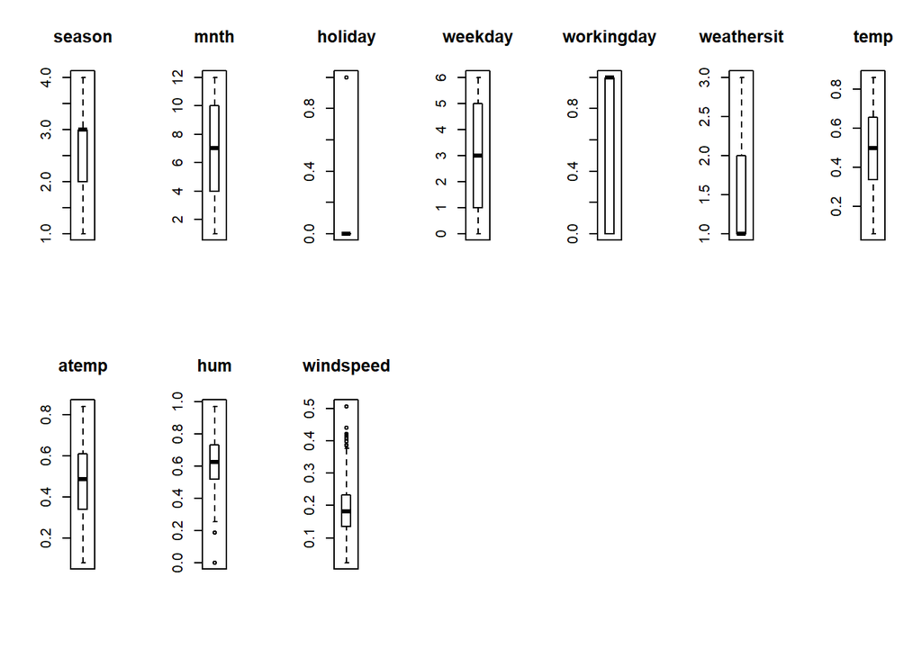

```r
# Boxplots for each attribute
par(mfrow=c(dispRow,dispCol))
for(i in 1:totAttr) {
    boxplot(entireDataset[,i], main=names(entireDataset)[i])
}
```

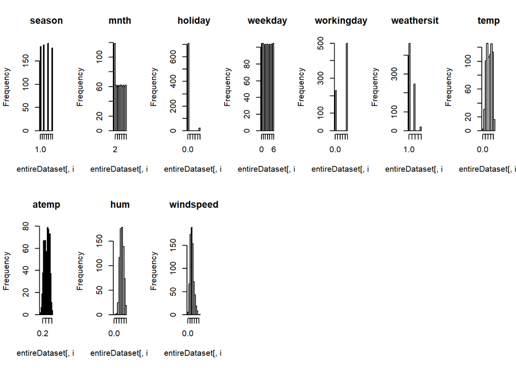

```r
# Histograms each attribute
par(mfrow=c(dispRow,dispCol))
for(i in 1:totAttr) {
    hist(entireDataset[,i], main=names(entireDataset)[i])
}
```

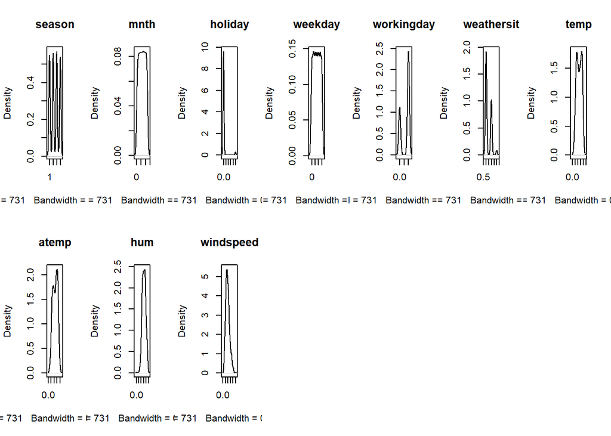

```r
# Density plot for each attribute
par(mfrow=c(dispRow,dispCol))
for(i in 1:totAttr) {
    plot(density(entireDataset[,i]), main=names(entireDataset)[i])
}
```

#### 2.b.ii) Multivariate plots to better understand the relationships between attributes

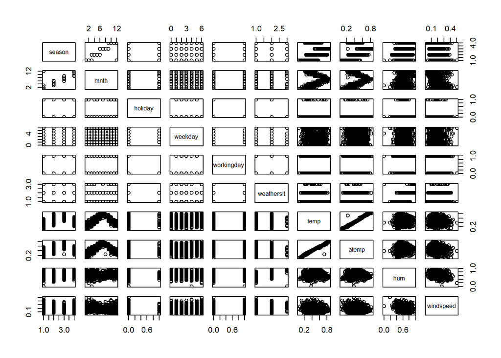

```r
# Scatterplot matrix colored by class
pairs(entireDataset[,1:totAttr])
```

```r
#pairs(targetVar~., data=entireDataset, col=training$targetVar)
```

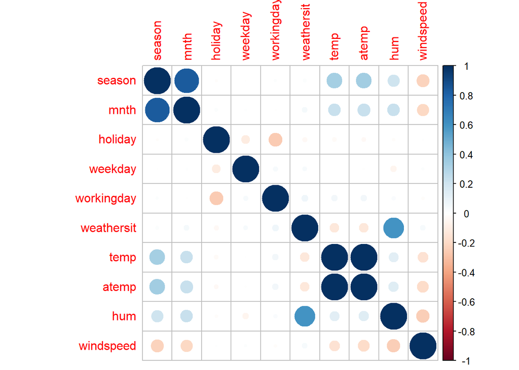

```r
# Correlation plot
correlations <- cor(entireDataset[,1:totAttr])
corrplot(correlations, method="circle")
```

## 3. Prepare Data

Some dataset may require additional preparation activities that will best exposes the structure of the problem and the relationships between the input attributes and the output variable. Some data-prep tasks might include:

- Cleaning data by removing duplicates, marking missing values and even imputing missing values.
- Feature selection where redundant features may be removed.
- Data transforms where attributes are scaled or redistributed in order to best expose the structure of the problem later to learning algorithms.

### 3.a) Data Cleaning

```r
# Not applicable for this iteration of the project.
```

### 3.b) Feature Selection

```r
# Not applicable for this iteration of the project.
```

### 3.c) Data Transformation

```r
# Not applicable for this iteration of the project.
```

### 3.d) Split-out training and validation datasets

We create a training dataset (variable name “training”) and a validation dataset (variable name “validation”).

```r
seedNum <- 888
set.seed(seedNum)

# Create a list of 70% of the rows in the original dataset we can use for training
training_index <- createDataPartition(entireDataset$targetVar, p=0.70, list=FALSE)

# Use 70% of data to training and testing the models
training <- entireDataset[training_index,]

# Select the remaining 30% of the data for validation
validation <- entireDataset[-training_index,]
```

```r
proc.time()-startTimeScript
```

```
##    user  system elapsed
##    1.00    1.89    3.00
```

## 4. Model and Evaluate Algorithms

After the data-prep, we next work on finding a workable model by evaluating a subset of machine learning algorithms that are good at exploiting the structure of the dataset. The typical evaluation tasks include:

- Defining test options such as cross validation and the evaluation metric to use.
- Spot checking a suite of linear and nonlinear machine learning algorithms.
- Comparing the estimated accuracy of algorithms.

For this iteration of the project, we will evaluate the model using just Stochastic Gradient Boosting.

The random number seed is reset before each run to ensure that the evaluation of each algorithm is performed using the same data splits. It ensures the results are directly comparable.

### 4.a) Set test options and evaluation metric

```r
# Run algorithms using 10-fold cross validation
control <- trainControl(method="repeatedcv", number=10, repeats=3)
metricTarget <- "RMSE"
```

### 4.b) Generate models

In this section, we will explore the use and tuning of ensemble algorithms to see whether we can improve the results.

```r
# Stochastic Gradient Boosting (Regression/Classification)
startTimeModule <- proc.time()
set.seed(seedNum)
fit.gbm.base <- train(targetVar~., data=training, method="gbm", metric=metricTarget, trControl=control, verbose=F)
print(fit.gbm.base)
```

```
## Stochastic Gradient Boosting
##
## 515 samples
##  10 predictor
##
## No pre-processing
## Resampling: Cross-Validated (10 fold, repeated 3 times)
## Summary of sample sizes: 464, 465, 463, 464, 463, 463, ...
## Resampling results across tuning parameters:
##
##   interaction.depth  n.trees  RMSE      Rsquared   MAE
##   1                   50      1306.461  0.5580877  1118.332
##   1                  100      1260.747  0.5823078  1091.688
##   1                  150      1258.595  0.5839196  1086.527
##   2                   50      1248.369  0.5903511  1076.457
##   2                  100      1240.562  0.5942970  1060.634
##   2                  150      1243.700  0.5930080  1059.904
##   3                   50      1243.585  0.5921913  1066.603
##   3                  100      1254.715  0.5859403  1064.291
##   3                  150      1258.277  0.5838472  1065.876
##
## Tuning parameter 'shrinkage' was held constant at a value of 0.1
##
## Tuning parameter 'n.minobsinnode' was held constant at a value of 10
## RMSE was used to select the optimal model using the smallest value.
## The final values used for the model were n.trees = 100,
##  interaction.depth = 2, shrinkage = 0.1 and n.minobsinnode = 10.
```

```r
proc.time()-startTimeModule
```

```
##    user  system elapsed
##    3.12    0.00    3.12
```

## Modeling Scenario #1

For this iteration, we remove the attribute “atemp” since it was highly correlated with the attribute “temp.”

### 3.b) Feature Selection

```r
entireDataset <- entireDataset.save
entireDataset$atemp <- NULL
```

### 3.d) Split-out training and validation datasets

We create a training dataset (variable name “training”) and a validation dataset (variable name “validation”).

```r
# Use 70% of data to training and testing the models
training1 <- entireDataset[training_index,]

# Select the remaining 30% of the data for validation
validation1 <- entireDataset[-training_index,]
```

### 4.b) Generate models

In this section, we will explore the use and tuning of ensemble algorithms to see whether we can improve the results.

```r
# Stochastic Gradient Boosting (Regression/Classification)
startTimeModule <- proc.time()
set.seed(seedNum)
fit.gbm.opt1 <- train(targetVar~., data=training1, method="gbm", metric=metricTarget, trControl=control, verbose=F)
print(fit.gbm.opt1)
```

```
## Stochastic Gradient Boosting
##
## 515 samples
##   9 predictor
##
## No pre-processing
## Resampling: Cross-Validated (10 fold, repeated 3 times)
## Summary of sample sizes: 464, 465, 463, 464, 463, 463, ...
## Resampling results across tuning parameters:
##
##   interaction.depth  n.trees  RMSE      Rsquared   MAE
##   1                   50      1299.534  0.5640923  1115.658
##   1                  100      1251.786  0.5884452  1087.566
##   1                  150      1249.329  0.5897525  1082.486
##   2                   50      1243.528  0.5941911  1074.561
##   2                  100      1238.391  0.5961812  1062.182
##   2                  150      1249.038  0.5900064  1066.350
##   3                   50      1233.482  0.5991116  1058.468
##   3                  100      1238.289  0.5965405  1053.237
##   3                  150      1248.686  0.5904939  1058.256
##
## Tuning parameter 'shrinkage' was held constant at a value of 0.1
##
## Tuning parameter 'n.minobsinnode' was held constant at a value of 10
## RMSE was used to select the optimal model using the smallest value.
## The final values used for the model were n.trees = 50, interaction.depth
##  = 3, shrinkage = 0.1 and n.minobsinnode = 10.
```

```r
proc.time()-startTimeModule
```

```
##    user  system elapsed
##    2.83    0.00    2.83
```

## End of Modeling Scenario #1

## Modeling Scenario #2

For this iteration, we perform one-hot-encoding on the variable “season.”

### 3.c) Data Transforms

```r
entireDataset <- entireDataset.save
season_dummy <- dummy(entireDataset$season, sep="_")
entireDataset <- cbind(season_dummy, entireDataset)
entireDataset$season <- NULL
```

### 3.d) Split-out training and validation datasets

We create a training dataset (variable name “training”) and a validation dataset (variable name “validation”).

```r
# Use 70% of data to training and testing the models
training2 <- entireDataset[training_index,]

# Select the remaining 30% of the data for validation
validation2 <- entireDataset[-training_index,]
```

### 4.b) Generate models

In this section, we will explore the use and tuning of ensemble algorithms to see whether we can improve the results.

```r
# Stochastic Gradient Boosting (Regression/Classification)
startTimeModule <- proc.time()
set.seed(seedNum)
fit.gbm.opt2 <- train(targetVar~., data=training2, method="gbm", metric=metricTarget, trControl=control, verbose=F)
print(fit.gbm.opt2)
```

```
## Stochastic Gradient Boosting
##
## 515 samples
##  13 predictor
##
## No pre-processing
## Resampling: Cross-Validated (10 fold, repeated 3 times)
## Summary of sample sizes: 464, 465, 463, 464, 463, 463, ...
## Resampling results across tuning parameters:
##
##   interaction.depth  n.trees  RMSE      Rsquared   MAE
##   1                   50      1306.367  0.5583488  1117.805
##   1                  100      1260.698  0.5823573  1090.792
##   1                  150      1259.235  0.5834126  1085.277
##   2                   50      1249.621  0.5896296  1075.881
##   2                  100      1241.493  0.5936922  1060.467
##   2                  150      1253.355  0.5872309  1065.202
##   3                   50      1243.411  0.5922875  1066.905
##   3                  100      1249.161  0.5892975  1061.690
##   3                  150      1255.286  0.5857344  1060.533
##
## Tuning parameter 'shrinkage' was held constant at a value of 0.1
##
## Tuning parameter 'n.minobsinnode' was held constant at a value of 10
## RMSE was used to select the optimal model using the smallest value.
## The final values used for the model were n.trees = 100,
##  interaction.depth = 2, shrinkage = 0.1 and n.minobsinnode = 10.
```

```r
proc.time()-startTimeModule
```

```
##    user  system elapsed
##    3.45    0.00    3.46
```

## End of Modeling Scenario #2

## Modeling Scenario #3

For this iteration, we perform one-hot-encoding on the variable “mnth.”

### 3.c) Data Transforms

```r
entireDataset <- entireDataset.save
month_dummy <- dummy(entireDataset$mnth, sep="_")
entireDataset <- cbind(month_dummy, entireDataset)
entireDataset$mnth <- NULL
```

### 3.d) Split-out training and validation datasets

We create a training dataset (variable name “training”) and a validation dataset (variable name “validation”).

```r
# Use 70% of data to training and testing the models
training3 <- entireDataset[training_index,]

# Select the remaining 30% of the data for validation
validation3 <- entireDataset[-training_index,]
```

### 4.b) Generate models

In this section, we will explore the use and tuning of ensemble algorithms to see whether we can improve the results.

```r
# Stochastic Gradient Boosting (Regression/Classification)
startTimeModule <- proc.time()
set.seed(seedNum)
fit.gbm.opt3 <- train(targetVar~., data=training3, method="gbm", metric=metricTarget, trControl=control, verbose=F)
print(fit.gbm.opt3)
```

```
## Stochastic Gradient Boosting
##
## 515 samples
##  21 predictor
##
## No pre-processing
## Resampling: Cross-Validated (10 fold, repeated 3 times)
## Summary of sample sizes: 464, 465, 463, 464, 463, 463, ...
## Resampling results across tuning parameters:
##
##   interaction.depth  n.trees  RMSE      Rsquared   MAE
##   1                   50      1306.236  0.5579369  1117.694
##   1                  100      1260.602  0.5820724  1090.254
##   1                  150      1259.761  0.5829337  1085.355
##   2                   50      1254.761  0.5862917  1079.709
##   2                  100      1247.605  0.5901366  1068.858
##   2                  150      1257.661  0.5840145  1073.603
##   3                   50      1245.152  0.5911487  1067.956
##   3                  100      1252.170  0.5874254  1062.024
##   3                  150      1254.593  0.5866003  1061.346
##
## Tuning parameter 'shrinkage' was held constant at a value of 0.1
##
## Tuning parameter 'n.minobsinnode' was held constant at a value of 10
## RMSE was used to select the optimal model using the smallest value.
## The final values used for the model were n.trees = 50, interaction.depth
##  = 3, shrinkage = 0.1 and n.minobsinnode = 10.
```

```r
proc.time()-startTimeModule
```

```
##    user  system elapsed
##    4.50    0.00    4.54
```

## End of Modeling Scenario #3

## 4. Model and Evaluate Algorithms

### 4.e) Compare baseline and optional models

```r
results <- resamples(list(GBMBASE=fit.gbm.base, GBM1=fit.gbm.opt1, GBM2=fit.gbm.opt2, GBM3=fit.gbm.opt3))
summary(results)
```

```
##
## Call:
## summary.resamples(object = results)
##
## Models: GBMBASE, GBM1, GBM2, GBM3
## Number of resamples: 30
##
## MAE
##             Min.  1st Qu.   Median     Mean  3rd Qu.     Max. NA's
## GBMBASE 860.7792 1015.785 1076.406 1060.634 1092.725 1321.619    0
## GBM1    892.4991 1011.505 1058.658 1058.468 1099.853 1279.186    0
## GBM2    854.7888 1007.664 1070.206 1060.467 1101.559 1323.407    0
## GBM3    880.1069 1039.923 1073.727 1067.956 1106.545 1283.689    0
##
## RMSE
##             Min.  1st Qu.   Median     Mean  3rd Qu.     Max. NA's
## GBMBASE 1031.308 1175.159 1258.469 1240.562 1291.210 1508.184    0
## GBM1    1058.141 1184.005 1245.514 1233.482 1281.231 1453.608    0
## GBM2    1025.488 1175.844 1254.965 1241.493 1290.298 1505.548    0
## GBM3    1049.932 1207.789 1253.270 1245.152 1279.589 1444.006    0
##
## Rsquared
##              Min.   1st Qu.    Median      Mean   3rd Qu.      Max. NA's
## GBMBASE 0.4228424 0.5551143 0.5877704 0.5942970 0.6398163 0.7136446    0
## GBM1    0.4625109 0.5625035 0.5910024 0.5991116 0.6326550 0.7244453    0
## GBM2    0.4233569 0.5614291 0.5820628 0.5936922 0.6453570 0.7125815    0
## GBM3    0.4670803 0.5568666 0.5827442 0.5911487 0.6114828 0.7203986    0
```

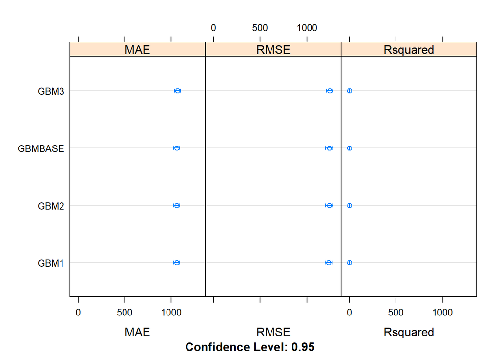

```r
dotplot(results)
```

## 5. Improve Accuracy or Results

After we achieve a short list of machine learning algorithms with good level of accuracy, we can leverage ways to improve the accuracy of the models.

### 5.a) Algorithm Tuning

Finally, we will tune the best-performing algorithms from each group further and see whether we can get more accuracy out of them.

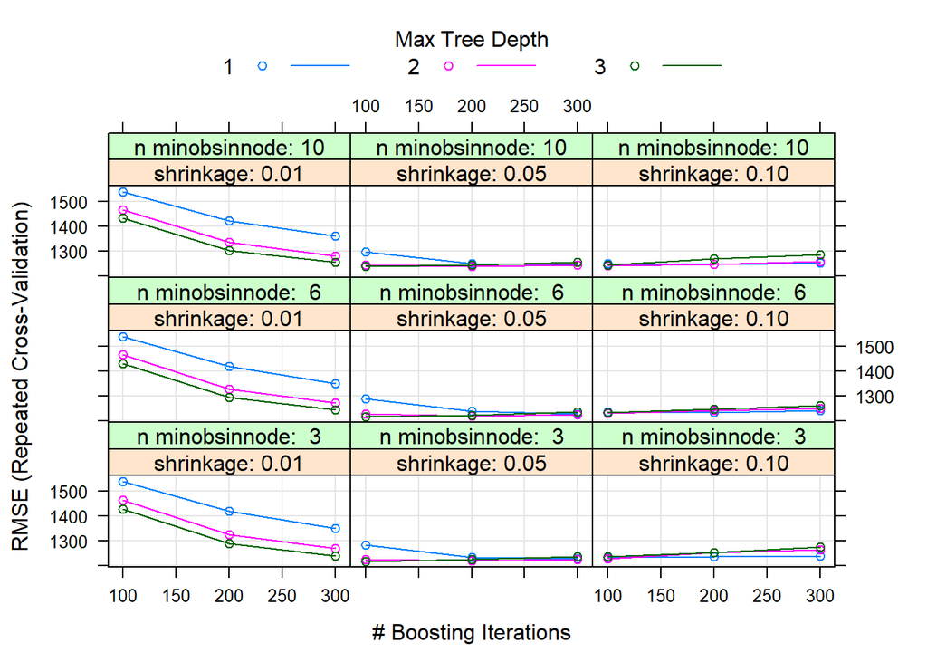

```r
# Reset the dataset to use modeling option #1
entireDataset <- entireDataset.save
entireDataset$atemp <- NULL
# Use variable totCol to hold the number of columns in the dataframe
totCol <- ncol(entireDataset)
# Use 70% of data to training and testing the models
training <- entireDataset[training_index,]
# Select the remaining 30% of the data for validation
validation <- entireDataset[-training_index,]

# Tuning algorithm - Stochastic Gradient Boosting
startTimeModule <- proc.time()
set.seed(seedNum)
grid <- expand.grid(.n.trees=c(100, 200, 300), .shrinkage=c(0.01, 0.05, 0.1), .interaction.depth=c(1, 2, 3), .n.minobsinnode=c(3, 6, 10))
fit.final <- train(targetVar~., data=training, method="gbm", metric=metricTarget, tuneGrid=grid, trControl=control, verbose=F)
plot(fit.final)
```

```r
print(fit.final)
```

```
## Stochastic Gradient Boosting
##
## 515 samples
##   9 predictor
##
## No pre-processing
## Resampling: Cross-Validated (10 fold, repeated 3 times)
## Summary of sample sizes: 464, 465, 463, 464, 463, 463, ...
## Resampling results across tuning parameters:
##
##   shrinkage  interaction.depth  n.minobsinnode  n.trees  RMSE
##   0.01       1                   3              100      1540.569
##   0.01       1                   3              200      1418.415
##   0.01       1                   3              300      1349.775
##   0.01       1                   6              100      1540.525
##   0.01       1                   6              200      1419.750
##   0.01       1                   6              300      1350.503
##   0.01       1                  10              100      1541.533
##   0.01       1                  10              200      1424.032
##   0.01       1                  10              300      1360.673
##   0.01       2                   3              100      1464.157
##   0.01       2                   3              200      1323.911
##   0.01       2                   3              300      1268.718
##   0.01       2                   6              100      1468.172
##   0.01       2                   6              200      1328.522
##   0.01       2                   6              300      1272.337
##   0.01       2                  10              100      1468.352
##   0.01       2                  10              200      1336.914
##   0.01       2                  10              300      1282.561
##   0.01       3                   3              100      1428.303
##   0.01       3                   3              200      1289.739
##   0.01       3                   3              300      1239.975
##   0.01       3                   6              100      1432.195
##   0.01       3                   6              200      1295.341
##   0.01       3                   6              300      1244.614
##   0.01       3                  10              100      1434.951
##   0.01       3                  10              200      1304.335
##   0.01       3                  10              300      1255.185
##   0.05       1                   3              100      1284.303
##   0.05       1                   3              200      1232.489
```

[output cut: 123 more lines]

```
##   0.5906718  1061.737
##   0.5829958  1066.172
##   0.5980560  1051.787
##   0.5870362  1055.125
##   0.5743984  1062.745
##   0.5992119  1053.244
##   0.5920393  1051.134
##   0.5842954  1057.634
##   0.5924547  1060.609
##   0.5777169  1069.330
##   0.5667716  1079.130
##
## RMSE was used to select the optimal model using the smallest value.
## The final values used for the model were n.trees = 100,
##  interaction.depth = 3, shrinkage = 0.05 and n.minobsinnode = 3.
```

```r
proc.time()-startTimeModule
```

```
##    user  system elapsed
##   36.88    0.07   37.28
```

## 6. Finalize Model and Present Results

Once we have narrow down to a model that we believe can make accurate predictions on unseen data, we are ready to finalize it. Finalizing a model may involve sub-tasks such as:

- Using an optimal model tuned to make predictions on unseen data.
- Creating a standalone model using the tuned parameters
- Saving an optimal model to file for later use.

### 6.a) Predictions on validation dataset

```r
predictions <- predict(fit.final, newdata=validation)
valY <- validation[,totCol]
print(RMSE(predictions, valY))
```

```
## [1] 1180.218
```

```r
print(R2(predictions, valY))
```

```
## [1] 0.6320685
```

### 6.b) Create standalone model on entire training dataset

```r
library(gbm)
startTimeModule <- proc.time()
set.seed(seedNum)
finalModel <- gbm(targetVar~., entireDataset, distribution = "gaussian", n.trees = 100, interaction.depth = 3, shrinkage = 0.05, n.minobsinnode = 3)
print(finalModel)
```

```
## gbm(formula = targetVar ~ ., distribution = "gaussian", data = entireDataset,
##     n.trees = 100, interaction.depth = 3, n.minobsinnode = 3,
##     shrinkage = 0.05)
## A gradient boosted model with gaussian loss function.
## 100 iterations were performed.
## There were 9 predictors of which 9 had non-zero influence.
```

```r
proc.time()-startTimeModule
```

```
##    user  system elapsed
##    0.05    0.00    0.04
```

### 6.c) Save model for later use

```r
#saveRDS(finalModel, "./finalModel_Regression.rds")
```

```r
proc.time()-startTimeScript
```

```
##    user  system elapsed
##   52.61    2.20   55.33
```